# t 검정, 비모수 검정, 그리고 큰 연구 — Fagerland (2012) 재현 (v2)

3주차 과제 · 제1종 오류율 모의실험

tjdgns1502

2026-09-21

# 요약

> **한 문장.** 평균도 같고 중앙값도 같은 두 치우친 분포에서 표본을 뽑아 표준편차만 10% 다르게 두면, Welch t 검정의 기각률은 어떤 표본크기에서도 5%에 머물지만 Wilcoxon 순위합(WMW) 검정의 기각률은 표본이 커질수록 올라가 각 군 1,000명에서 감마 분포 쌍의 경우 **98.4%**에 이른다(논문 99%). 이것은 WMW의 오류가 아니라 **자기 귀무가설 P(X < Y) = 0.5에 대한 검정력**이며, 틀린 것은 그 p값을 “중앙값이 다르다”로 번역하는 해석이다.

이 보고서에서 **가장 중요한 세 가지 발견**은 다음과 같다.

1. **논문의 분포 구성은 중앙값이 같지 않다.** 논문은 “평균·중앙값·왜도가 같고 표준편차만 다르다”고 서술하지만 이는 모수 3개에 제약 4개로 불가능하다. {평균, 왜도, 표준편차비}를 정확히 맞추고 중앙값을 포기한 구성 $Y = \mu_X + r(X-\mu_X)$ 이 논문의 표 2를 반올림 수준으로, 표 4·표 5를 각 군 50명 이상에서 0.4%p 이내로 **재현**한다(§5.3). 각 군 25명 이하는 WMW 근사 방식 차이로 벗어난다(§5.4). 중앙값을 맞추는 구성은 재현하지 못한다.
2. **논문의 n = 10 값은 R 기본 `wilcox.test()` 설정과 일치한다.** 과제가 강제한 `exact = FALSE, correct = FALSE`는 n = 10에서 기각률을 1.0–1.5%p 부풀리며, 연속성 보정 근사·R 기본값·정확검정으로 바꾸면 논문 값과 **0.02%p 이내**로 일치한다. 이 세 변형은 n = 10에서 칸별로 완전히 같아서 서로 구분되지 않는다(§5.4).
3. **편이 감마족은 왜도 3.75에서 뒤집힌다.** 평균·중앙값을 고정하면 도달 가능한 표준편차가 형상모수 $k^{*} = 0.2847$ (왜도 3.748)에서 최소가 되므로, 왜도 4인 감마 기준분포는 이 경계를 넘어 있어 Y가 **덜** 치우치는 대신 **더** 치우치고 P(X<Y)가 0.5의 반대편으로 넘어간다(§4.2).

# 1 논문이 말하는 역설

Fagerland는 서로 반대 방향으로 간 두 추세를 지적한다. 고영향 의학저널의 연구 표본크기는 1970년대 30명대에서 2000년대 3,000명대로 약 100배 커졌는데, 같은 기간 t 검정 사용 비율은 44% → 26%로 줄고 비모수 검정은 11% → 27%로 늘었다.

이것이 역설인 이유는 두 검정이 표본크기에 정반대로 반응하기 때문이다.

- **t 검정**은 중심극한정리 덕분에 표본이 커질수록 정규성 위반에 **강해진다**.
- **WMW 검정**은 표본이 커질수록 위치 이외의 분포 차이(퍼짐, 모양)를 잡아내는 능력이 **커진다**.

연구가 커질수록 비모수 검정의 비율은 줄어야 맞는데 실제로는 늘었다.

## 1.1 실험의 논리 구조

평균과 중앙값을 **같게** 만들면 “평균 차이 없음”과 “중앙값 차이 없음”이라는 두 귀무가설이 모두 참이다. 이 상태에서 일어나는 기각은 그 두 가설에 대해서는 제1종 오류다. 그런데 표준편차를 조금 다르게 두면 WMW의 **진짜** 귀무가설 $P(X<Y) = 0.5$ 는 거짓이 된다. 그래서 WMW의 높은 기각률은 오류가 아니라 검정력이다.

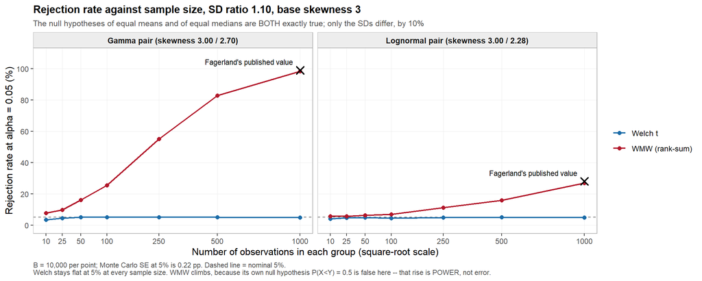

그림 5. 표본크기에 따른 기각률. 평균과 중앙값이 모두 정확히 같고 표준편차만 10% 다른 쌍. Welch는 어느 표본크기에서도 5%에 머물고 WMW는 단조 증가한다. ×는 Fagerland가 발표한 값이다.

# 2 통계 — 비교하는 검정들

| 검정 | 귀무가설 | 이 과제에서의 역할 |
| --- | --- | --- |
| Student t (합동분산) | $\mu_1 = \mu_2$ (등분산 가정) | 등분산 위반의 피해자. 비교 기준 |
| **Welch t** | $\mu_1 = \mu_2$ (등분산 가정 없음) | **논문이 “t 검정”이라 부른 것.** 기본 검정 |
| 대응 t | $\mu_d = 0$ | 짝 구조의 정보 이득을 보이는 용도 |
| **WMW 순위합** | $P(X<Y) = 0.5$ | **역설의 주인공** |
| Wilcoxon 부호순위 | 짝 차이 분포의 대칭 중심 = 0 | 대응 자료용. 순위합과 **다른** 검정 |
| 순열검정 | 두 군의 분포가 동일(교환가능) | “비모수면 안전하다”는 통념의 반례 |

**`t.test()`의 `var.equal` 기본값은 `FALSE`** 이며 이 과제는 의도적으로 그것을 사용한다. Student t는 비교 목적으로만 `var.equal = TRUE` 를 명시해 호출한다.

## 2.1 빠른 구현과 그 검증

448칸 × 10,000회 = 448만 번의 검정을 수행해야 하므로 `t.test()` / `wilcox.test()`의 formula 처리·클래스 생성 비용을 피하고 통계량을 직접 계산했다(`R/00_utils.R`). 그 대신 **500개의 무작위 설계** (불균등 n, 불균등 SD, 그중 166개는 동점이 많도록 반올림) 에서 base R 함수와 일치하는지 검증했다.

[output not shown]

동점 보정 분산을 쓴 `wmw_p()`가 `wilcox.test(exact = FALSE, correct = FALSE)`와 1.11e-16 이내로 일치하므로, 격자 실험에서 쓰는 빠른 함수는 base R과 같은 검정이다.

# 3 검증 과제 ① — Satterthwaite 자유도

## 3.1 왜 자유도가 소수인가

Welch 통계량의 분모 안에 있는 $s_1^2/n_1 + s_2^2/n_2$ 는 **자유도가 다른 두 $\chi^2$ 변수의 가중합**이다. 가중합은 일반적으로 $\chi^2$ 분포를 따르지 않으므로 정확한 자유도가 존재하지 않는다. Satterthwaite의 아이디어는 이 가중합을 $c \cdot \chi^2_\nu/\nu$ 라는 **하나의** 척도화된 $\chi^2$ 로 근사하되, 근사 분포의 **평균과 분산이 원래 것과 같아지도록** $c$ 와 $\nu$ 를 정하는 것이다(적률 적합, moment matching). 평균을 맞추는 조건과 분산을 맞추는 조건 두 개를 연립해 풀면 $\nu$ 가 표본분산들의 연속함수로 나오고, 연속함수 값이 정수일 이유는 없으므로 **$\nu$ 는 일반적으로 소수**가 된다. 정수 자유도는 $s_1^2/n_1$ 과 $s_2^2/n_2$ 의 비가 특정한 값일 때 우연히 나오는 특수해일 뿐이다.

$$\nu = \frac{\left(\frac{s_1^2}{n_1} +
\frac{s_2^2}{n_2}\right)^2}
{\dfrac{(s_1^2/n_1)^2}{n_1-1} +
\dfrac{(s_2^2/n_2)^2}{n_2-1}}$$

## 3.2 자유도와 p값 모두 일치하는가

표 2. Satterthwaite 구현은 자유도뿐 아니라 p값까지 t.test()와 일치한다.

| 항목 | 값 |
| --- | --- |
| 무작위 설계 500개에서 max \|nu_mine - nu_R\| | 1.14e-13 |
| 최대 상대 오차 (자유도) | 9.87e-16 |
| 무작위 설계 500개에서 max \|p_mine - p_R\| | 3.33e-16 |

## 3.3 반드시 함께 검증할 성질 (모두 코드로 확인)

표 3. nu의 네 가지 구조적 성질. 모두 산문이 아니라 코드로 확인했다.

| 성질 | 결과 |
| --- | --- |
| 범위 min(n1,n2)-1 <= nu <= n1+n2-2 | TRUE |
| (극단 설계 20,000건 스트레스 테스트) | TRUE |
| 한쪽 분산이 압도 -> nu -> 그 군의 n-1 (군2, n2=40) | 분산비 1e8 에서 nu = 39.0000 (극한 39) |
| 한쪽 분산이 압도 -> nu -> 그 군의 n-1 (군1, n1=12) | 분산비 1e8 에서 nu = 11.0000 (극한 11) |
| n1=n2 이고 s1=s2 -> nu = n1+n2-2 | max \|nu - (n1+n2-2)\| = 5.68e-14 |
| 같은 경우 Welch p == Student p | max \|p_W - p_S\| = 8.33e-17 |

상한이 **정확히 도달 가능**하다는 점은 대수적으로도 확인된다. $a = s_1^2/n_1$, $b = s_2^2/n_2$ 라 두고 $t = a/(a+b)$ 로 쓰면 $\nu = 1/\{t^2/(n_1-1) + (1-t)^2/(n_2-1)\}$ 이고, 이를 최대화하는 $t = (n_1-1)/(n_1+n_2-2)$ 에서 $\nu = n_1+n_2-2$ 가 된다. 아래 표본분포에서 최댓값이 정확히 38.000인 것이 이 때문이다.

## 3.4 $\nu$ 는 확률변수다

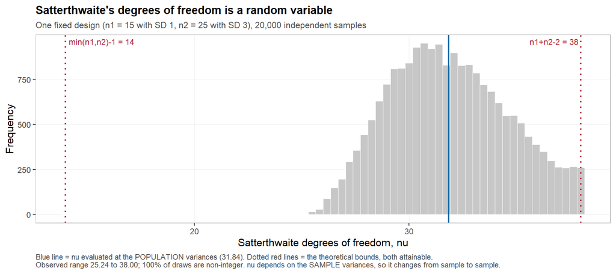

그림 8. 같은 설계(n1=15, SD 1; n2=25, SD 3)를 20,000번 반복해 얻은 Satterthwaite 자유도의 표본분포. 설계가 고정되어 있어도 표본분산에 의존하므로 자유도는 표본마다 달라진다.

표 4. nu의 표본분포 요약. 관측 범위가 이론적 하한/상한 안에 있고 상한 38은 실제로 도달한다.

| 통계량 | 값 |
| --- | --- |
| 최솟값 | 25.237 |
| 5% 분위수 | 27.622 |
| 중앙값 | 31.700 |
| 평균 | 31.899 |
| 95% 분위수 | 36.848 |
| 최댓값 | 38.000 |
| 표준편차 | 2.766 |
| 이론적 하한 min(n1,n2)-1 | 14 |
| 이론적 상한 n1+n2-2 | 38 |
| 모분산에서 계산한 nu | 31.840 |
| 비정수 비율 | 100.0% |

# 4 자료 구성 — 제약 4개 대 모수 3개

## 4.1 문제의 핵심

논문은 두 분포가 “평균·중앙값·왜도가 같고 표준편차만 다르다”고 서술한다. 맞춰야 할 값을 세면 **네 개**(평균, 중앙값, 표준편차, 왜도)다. 그런데

- 로그정규 = 모수 2개 ($\mu, \sigma$)
- 편이 로그정규 $\gamma + e^{\mu+\sigma Z}$ = 모수 **3개**
- 감마 = 모수 2개, 편이 감마 $\gamma + \mathrm{Gamma}(k,\theta)$ = 모수 **3개**

이므로 **세 모수 족 안에서 네 조건을 동시에 만족시킬 수 없다.** 이는 논문 본문만으로 정확한 구성이 복원되지 않는 지점이며, 재현 보고서에서 반드시 짚어야 하는 부분이다.

**주 구성(main)에서 내린 결정:** 평균·중앙값·표준편차비 세 개를 정확히 맞추고 **왜도는 결과로 받아들인다.** 이유는 논문의 논증 구조가 요구하는 것이 “평균 동일 **그리고** 중앙값 동일”이기 때문이다. 이 둘이 정확히 성립해야 “기각은 전부 제1종 오류”라는 문장이 성립한다.

### 4.1.1 해가 1차원 근찾기로 환원된다

편이 로그정규에서 $A = e^\mu$, $k = e^{\sigma^2/2}$ 로 두면

$$\text{중앙값: } \gamma + A = m_e, \quad
\text{평균: } \gamma + Ak = m, \quad
\text{표준편차: } Ak\sqrt{k^2-1} = s$$

앞의 두 식에서 $A = (m - m_e)/(k-1)$ 이 나오므로 남는 것은 $k$ 에 대한 **한 개**의 방정식

$$(m - m_e)\, k \sqrt{\frac{k+1}{k-1}} =
s$$

이다. 즉 `optim`이 아니라 `uniroot` 로 풀린다. 좌변은 $k = \varphi = (1+\sqrt5)/2$ (황금비)에서 최소가 되므로 근이 **둘** 있고, 비율 → 1 일 때 기준분포 자신으로 수렴하는 가지인 $k \in (1, \varphi)$ 를 택한다. 감마도 같은 구조이며 중앙값 조건에 `qgamma` 가 들어간다.

## 4.2 도달 가능한 표준편차의 전환점 — 감마족은 왜도 3.75에서 뒤집힌다

표 5. 평균·중앙값을 고정했을 때 도달 가능한 표준편차가 최소가 되는 지점.

| 분포족 | 전환점 형상모수 | 전환점 왜도 | 과제의 왜도 1~4 |
| --- | --- | --- | --- |
| 감마 | k* = 0.28471 | 3.7482 | 왜도 4는 경계를 **넘음** |
| 로그정규 | k = phi = 1.61803 | 5.8742 | 네 수준 모두 경계 안 |

기준분포가 전환점보다 **덜** 치우쳐 있으면(감마 왜도 1·2·3, 로그정규 전부) Y를 넓히려면 형상모수를 키워야 하고 따라서 Y가 **덜** 치우친다. 이것이 과제 안내서가 말한 “평균과 중앙값을 고정하면 덜 치우친 쪽이 더 큰 표준편차를 갖는다”의 정확한 내용이다. 평균과 중앙값의 간격은 고정인데 왜도가 낮으면 그 간격을 만들기 위해 퍼짐이 더 커져야 하기 때문이다.

그런데 **감마 왜도 4**($k = 0.25$)는 전환점 $k^{*} = 0.2847$ 보다 작은 쪽에 있다. 도달 가능한 최소 표준편차보다 겨우 0.44% 위에 놓인 칼날 위의 위치다. 그 결과 Y를 넓히면 오히려 **더** 치우치고 ($4.68$ → $7.26$), $P(X<Y)$ 가 0.5의 **반대편**으로 넘어간다. 이는 코딩 오류가 아니라 세 모수 족의 수학적 한계이며, 주 구성으로는 논문의 감마 왜도 4 열을 재현할 수 없음을 뜻한다.

## 4.3 64개 쌍의 수렴 잔차 — 하나도 숨기지 않는다

표 6. 64개 쌍 전부의 수렴 잔차. 기준 1e-9을 모두 통과했고, 하나라도 넘으면 스크립트가 stop()으로 중단되도록 작성했다.

| 항목 | 64쌍 최대값 |
| --- | --- |
| 근찾기 잔차 \|h(k) - s\| | 1.70e-12 |
| \|평균(Y) - 평균(X)\| | 8.88e-16 |
| \|중앙값(Y) - 중앙값(X)\| | 4.44e-16 |
| \|SD(Y) - 목표 SD\| | 1.70e-12 |
| \|SD비 - 목표비\| | 2.08e-12 |
| P(X<Y) 수치적분 절대오차 | 9.71e-13 |

> 개발 중 이 검사가 실제로 실패했다. `fit_shifted_gamma()` 에서 이동량을 **평균** 조건으로 잡아(`med - theta*k`) 중앙값이 어긋났고, 잔차 표가 `err_mean = err_median = m - m_e` 라는 특징적인 값을 보여 원인을 바로 짚을 수 있었다. 올바른 식은 중앙값 조건 `gamma = med - theta * qgamma(0.5, k)` 이다.

## 4.4 대표본 검증 (각 분포 2e+06개 난수)

표 7. 난수 2e+06개로 추정한 값과 모수에서 계산한 정확값의 차이(64쌍 최대). P(X<Y)의 몬테카를로 표준오차는 0.00035이다. 표본왜도는 오른쪽 꼬리가 긴 분포에서 가장 늦게 수렴하므로 편차가 가장 크다.

| 항목 | max \|경험적 - 정확값\| |
| --- | --- |
| 평균 (X) | 0.01181 |
| 평균 (Y) | 0.02674 |
| 중앙값 (X) | 0.00591 |
| 중앙값 (Y) | 0.00725 |
| 표준편차 (X) | 0.03973 |
| 표준편차 (Y) | 0.13265 |
| 왜도 (X) | 0.20065 |
| 왜도 (Y) | 0.05150 |
| P(X<Y) | 0.00095 |

## 4.5 안내서의 로그정규 참조표 재현

표 8. 과제 안내서의 로그정규 참조표(왜도 3)와의 대조.

| SD비 | 내 gamma | 안내서 | 내 meanlog | 안내서 | 내 sdlog | 안내서 | 내 SD | 안내서 | 내 왜도 | 안내서 |
| --- | --- | --- | --- | --- | --- | --- | --- | --- | --- | --- |
| base X | 0.0000 | 0.0000 | 0.0000 | 0.0000 | 0.71557 | 0.71557 | 1.0563 | 1.0563 | 3.00 | 3.00 |
| 1.05 | -0.2323 | -0.2323 | 0.2089 | 0.2098 | 0.65192 | 0.65190 | 1.1091 | 1.1091 | 2.57 | 2.57 |
| 1.10 | -0.4620 | -0.4620 | 0.3798 | 0.3796 | 0.60328 | 0.60330 | 1.1620 | 1.1620 | 2.28 | 2.28 |
| 1.15 | -0.6945 | -0.6945 | 0.5274 | 0.5274 | 0.56368 | 0.56370 | 1.2148 | 1.2148 | 2.06 | 2.06 |
| 1.20 | -0.9326 | -0.9326 | 0.6589 | 0.6590 | 0.53030 | 0.53030 | 1.2676 | 1.2676 | 1.89 | 1.89 |

**결론: `gamma`, `sdlog`, `SD`, `왜도` 네 열은 안내서와 인쇄된 자릿수까지 완전히 일치한다.** `meanlog` 열만 어긋나는데(최대 9e-4), 이것은 내 계산이 틀려서가 아니라 **안내서의 표가 자기 자신과 모순되기 때문**이다. 구성상 $\texttt{meanlog} = \log(A) = \log(m_e - \gamma) = \log(1-\gamma)$ 여야 하는데, 안내서가 인쇄한 $\gamma$ 값으로 역산하면 내 값이 나온다.

표 9. 안내서의 meanlog 열 자체 검증. 안내서의 gamma 열로 log(1-gamma)를 계산하면 내 값과 일치한다(최대 차이 3.38e-05). SD비 1.05 행의 0.2098은 0.2089의 자릿수 뒤바뀜으로 보인다.

| SD비 | 안내서 gamma | 안내서 meanlog(인쇄) | 안내서 gamma로 역산 | 내 값 |
| --- | --- | --- | --- | --- |
| base X | 0.0000 | 0.0000 | 0.0000 | 0.0000 |
| 1.05 | -0.2323 | 0.2098 | 0.2089 | 0.2089 |
| 1.10 | -0.4620 | 0.3796 | 0.3798 | 0.3798 |
| 1.15 | -0.6945 | 0.5274 | 0.5274 | 0.5274 |
| 1.20 | -0.9326 | 0.6590 | 0.6589 | 0.6589 |

또한 안내서의 반례 B 코드가 쓴 `meanlog = log(1.46200) = 0.37988` 역시 표에 인쇄된 0.3796이 아니라 내 값 0.3798 쪽과 맞는다.

## 4.6 논문 표 2 (참 $P(X<Y)$) 와의 대조

**라벨 방향 주의.** 논문은 “X의 표준편차가 Y보다 10% 크다”고 하여 **X가 넓은 쪽**이고 $P(X<Y) > 0.5$ 이다. 반면 과제 지시는 $\mathrm{SD}(Y) = r\cdot \mathrm{SD}(X)$ 로 **Y가 넓은 쪽**이다. 연속분포이므로 $P_{\text{논문}} = 1 - P_{\text{과제}}$ 이며, 아래 표는 전부 **논문 라벨**로 환산했다. 안내서가 반례 B에서 $P(X<Y) = 0.4824$ 라 한 것도 과제 라벨 기준이고, $1 - 0.4824 = 0.5176 \approx 0.52$ 가 논문 값이다.

표 10a. 감마: 내 정확값 / 논문 표 2. 왜도 4 열이 크게 어긋나는 것이 §4.2의 전환점 문제다.

|  | 왜도 1 | 왜도 2 | 왜도 3 | 왜도 4 |
| --- | --- | --- | --- | --- |
| SD비 1.05 | 0.503 / 0.50 | 0.512 / 0.51 | 0.544 / 0.54 | 0.410 / 0.58 |
| SD비 1.10 | 0.505 / 0.51 | 0.520 / 0.52 | 0.553 / 0.56 | 0.404 / 0.61 |
| SD비 1.15 | 0.507 / 0.51 | 0.525 / 0.53 | 0.558 / 0.57 | 0.404 / 0.62 |
| SD비 1.20 | 0.509 / 0.52 | 0.529 / 0.54 | 0.560 / 0.58 | 0.405 / 0.64 |
| SD비 1.25 | 0.511 / 0.52 | 0.532 / 0.54 | 0.562 / 0.59 | 0.407 / 0.64 |
| SD비 1.30 | 0.512 / 0.52 | 0.534 / 0.55 | 0.562 / 0.60 | 0.410 / 0.66 |
| SD비 1.40 | 0.514 / 0.53 | 0.537 / 0.56 | 0.562 / 0.61 | 0.416 / 0.67 |
| SD비 1.50 | 0.516 / 0.53 | 0.539 / 0.57 | 0.562 / 0.62 | 0.421 / 0.68 |

표 10b. 로그정규: 내 정확값 / 논문 표 2.

|  | 왜도 1 | 왜도 2 | 왜도 3 | 왜도 4 |
| --- | --- | --- | --- | --- |
| SD비 1.05 | 0.502 / 0.50 | 0.506 / 0.51 | 0.510 / 0.51 | 0.517 / 0.51 |
| SD비 1.10 | 0.505 / 0.51 | 0.510 / 0.51 | 0.517 / 0.52 | 0.525 / 0.52 |
| SD비 1.15 | 0.506 / 0.51 | 0.514 / 0.52 | 0.522 / 0.53 | 0.530 / 0.53 |
| SD비 1.20 | 0.508 / 0.52 | 0.517 / 0.53 | 0.526 / 0.53 | 0.534 / 0.54 |
| SD비 1.25 | 0.509 / 0.52 | 0.519 / 0.53 | 0.529 / 0.54 | 0.536 / 0.56 |
| SD비 1.30 | 0.511 / 0.52 | 0.521 / 0.53 | 0.531 / 0.55 | 0.538 / 0.55 |
| SD비 1.40 | 0.513 / 0.52 | 0.524 / 0.54 | 0.533 / 0.56 | 0.539 / 0.57 |
| SD비 1.50 | 0.514 / 0.53 | 0.526 / 0.55 | 0.535 / 0.56 | 0.540 / 0.58 |

표 11. 두 가지 3-제약 구성 중 어느 쪽이 논문 표 2에 가까운가.

| 구성 | 분포족 | 논문과의 최대 절대차 | 논문과의 평균 절대차 |
| --- | --- | --- | --- |
| main {mean, median, SD} (equal-median) | gamma | 0.2586 | 0.0688 |
| main {mean, median, SD} (equal-median) | lognormal | 0.0399 | 0.0117 |
| sens. B {mean, skew, SD} (equal-skewness) | gamma | 0.0064 | 0.0026 |
| sens. B {mean, skew, SD} (equal-skewness) | lognormal | 0.0118 | 0.0032 |

**이것이 이 보고서의 가장 중요한 발견이다.** 중앙값을 맞춘 주 구성은 논문 표 2와 감마에서 최대 0.259 어긋나지만, **왜도를 맞추고 중앙값을 포기한 구성(민감도 B)** 은 감마 최대 0.006, 로그정규 최대 0.012 로 **64칸 전부가 논문 값 가까이** 들어온다. 논문이 2자리로 인쇄했으므로 반올림만으로 ±0.005가 생기는데, 최대 차이(감마 0.006, 로그정규 0.012)가 그 수준에 가깝다.

민감도 B의 구성은 $Y = \mu_X + r(X - \mu_X)$, 즉 X를 자기 평균 둘레로 $r$ 배 확대한 것이다. 평균과 왜도는 정확히 보존되고 중앙값이 $(r-1)(\mu_X - m_{e,X})$ 만큼 이동한다. 감마 왜도 4·SD비 1.5에서는 그 이동이 $-2.362$ 로, 중앙값 1 대비 결코 작지 않다. **따라서 논문의 “중앙값이 같다”는 서술은 논문 자신의 표 2와 양립하지 않는다.**

과제 지시에 따라 **주 구성은 그대로 중앙값을 맞추는 쪽으로 유지**한다. 숫자가 더 예뻐 보인다는 이유로 주 구성을 바꾸지 않는다. 주 구성만이 “평균 동일 **그리고** 중앙값 동일”을 정확히 성립시키고, 그것이 제1종 오류 논증에 필요한 조건이기 때문이다.

# 5 모의실험 결과와 논문 비교

## 5.1 이분산 정규분포 기준선

정규성은 완벽하고 등분산만 깨진 자료에서 Student와 Welch의 차이만 순수하게 드러난다(총 N = 50 고정).

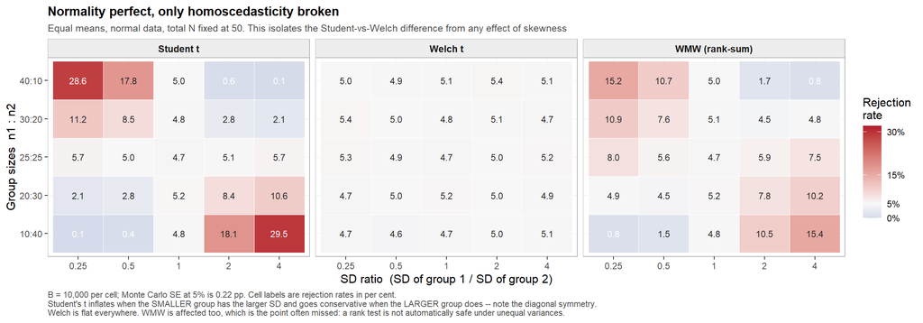

그림 6. 정규성은 완벽하고 등분산만 깨진 경우. B = 10,000, 몬테카를로 표준오차 0.22%p.

표 12. 안내서가 예고한 네 가지 패턴. 모두 성립한다.

| 주장 | 관측값 | 성립 |
| --- | --- | --- |
| small group has the larger SD -> Student INFLATES | Student 8.4% - 29.5% (vs 5.0%) | TRUE |
| large group has the larger SD -> Student CONSERVATIVE | Student 0.1% - 2.8% (vs 5.0%) | TRUE |
| Welch stays near 5% everywhere | Welch 4.6% - 5.4% over all 25 cells | TRUE |
| equal n -> Student roughly OK | Student 4.7% - 5.7% when n1 = n2 | TRUE |

한 가지 덧붙일 점: **WMW 역시 이분산 + 불균등 n 에서 무너진다** (0.8% ~ 15.4%). “비모수면 안전하다”는 통념은 여기서도 틀린다.

## 5.2 448칸 주 격자

표 13. 논문 표 3 형태 — 감마, 각 군 1000명, WMW 기각률(%). 내 값 / 논문 값.

|  | 왜도 1 | 왜도 2 | 왜도 3 | 왜도 4 |
| --- | --- | --- | --- | --- |
| SD비 1.05 | 5.3 / 5.8 | 16.1 / 14.4 | 91.6 / 78.6 | 100.0 / 100.0 |
| SD비 1.10 | 6.9 / 8.6 | 34.4 / 39.1 | 98.4 / 98.8 | 100.0 / 100.0 |
| SD비 1.15 | 8.7 / 13.6 | 49.6 / 65.7 | 99.2 / 100.0 | 100.0 / 100.0 |
| SD비 1.20 | 10.8 / 19.6 | 61.0 / 83.7 | 99.5 / 100.0 | 100.0 / 100.0 |
| SD비 1.25 | 13.4 / 26.1 | 70.0 / 93.8 | 99.6 / 100.0 | 100.0 / 100.0 |
| SD비 1.30 | 16.0 / 33.9 | 75.5 / 97.7 | 99.6 / 100.0 | 100.0 / 100.0 |
| SD비 1.40 | 19.8 / 48.9 | 80.3 / 99.8 | 99.7 / 100.0 | 100.0 / 100.0 |
| SD비 1.50 | 23.7 / 61.7 | 83.4 / 100.0 | 99.5 / 100.0 | 100.0 / 100.0 |

표 14. 논문 표 3 형태 — 감마, 각 군 1000명, Welch t 기각률(%). 내 값 / 논문 값. 모두 5% 부근이다.

|  | 왜도 1 | 왜도 2 | 왜도 3 | 왜도 4 |
| --- | --- | --- | --- | --- |
| SD비 1.05 | 4.9 / 4.8 | 5.4 / 4.4 | 5.2 / 4.9 | 4.8 / 4.8 |
| SD비 1.10 | 5.1 / 4.8 | 5.1 / 5.0 | 4.9 / 5.1 | 4.6 / 4.9 |
| SD비 1.15 | 4.8 / 5.5 | 4.9 / 4.8 | 5.0 / 5.1 | 4.9 / 5.2 |
| SD비 1.20 | 4.9 / 5.0 | 4.9 / 4.7 | 5.0 / 5.2 | 4.9 / 5.2 |
| SD비 1.25 | 4.9 / 5.7 | 5.2 / 4.7 | 4.6 / 5.0 | 4.6 / 5.1 |
| SD비 1.30 | 4.9 / 4.9 | 5.3 / 5.0 | 5.2 / 4.4 | 4.9 / 5.1 |
| SD비 1.40 | 5.1 / 4.9 | 5.5 / 5.0 | 4.6 / 5.0 | 5.1 / 4.8 |
| SD비 1.50 | 5.2 / 4.7 | 5.0 / 5.0 | 5.3 / 4.9 | 5.1 / 5.3 |

논문의 가장 강한 수치와 직접 대조하면:

표 15. 논문 초록·본문이 강조한 핵심 수치와의 직접 대조.

| 조건 | WMW (내 값) | WMW (논문) | t (내 값) | t (논문) |
| --- | --- | --- | --- | --- |
| 감마, 왜도 3, SD비 1.10, n=1000 | 98.4% | 99% | 4.9% | 5.1% |
| 로그정규, 왜도 3, SD비 1.10, n=1000 | 27.0% | 28% | 4.7% | 4.9% |

**논문의 헤드라인 수치는 주 구성으로도 잘 재현된다.** 중앙값을 맞추는 구성은 논문과 다른 분포를 쓰지만, 왜도 3 · SD비 1.10 조건에서는 두 구성이 만드는 $|P(X<Y)-0.5|$ 가 비슷하기 때문이다.

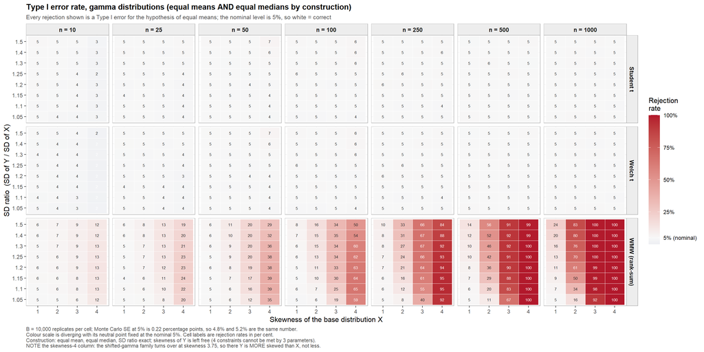

그림 4a. 감마 분포 쌍의 제1종 오류율 격자. 색 눈금의 중립점은 명목 5%에 고정했다.

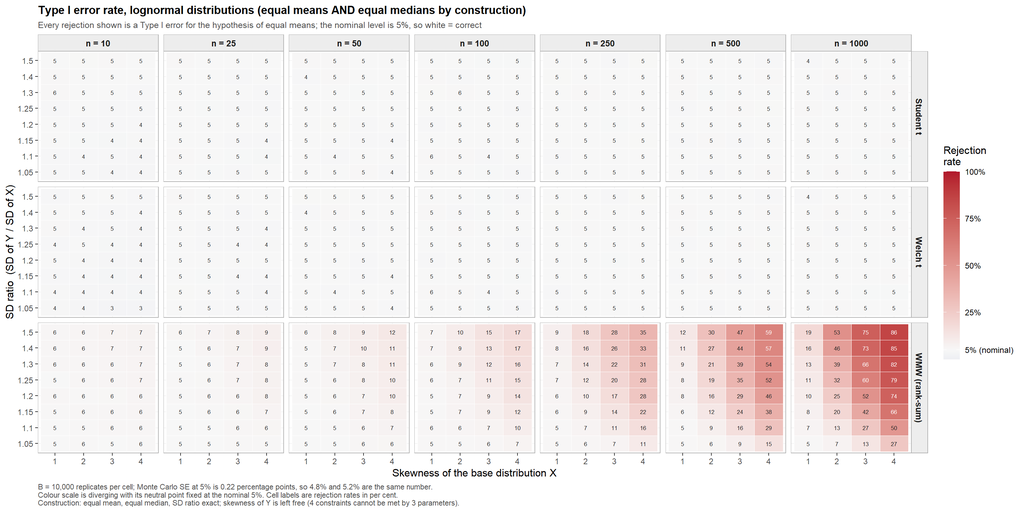

그림 4b. 로그정규 분포 쌍의 제1종 오류율 격자.

## 5.3 표 4 · 표 5 — 민감도 B가 논문을 재현한다

표 16a. 논문 표 4 형태 — 감마. 32개 시나리오 평균 기각률(%).

| 각 군 n | 논문 t | 주구성 Welch | 민감도B Welch | 논문 WMW | 주구성 WMW | 민감도B WMW |
| --- | --- | --- | --- | --- | --- | --- |
| 10 | 4.01 | 3.61 | 4.01 | 9.47 | 8.12 | 10.90 |
| 25 | 4.71 | 4.58 | 4.69 | 18.00 | 11.27 | 18.31 |
| 50 | 4.91 | 4.86 | 4.92 | 28.90 | 16.94 | 28.85 |
| 100 | 4.98 | 5.06 | 4.99 | 41.60 | 26.82 | 41.55 |
| 250 | 4.95 | 5.04 | 5.02 | 56.90 | 45.29 | 56.90 |
| 500 | 4.99 | 5.03 | 4.95 | 66.30 | 57.99 | 66.47 |
| 1000 | 4.97 | 4.99 | 4.95 | 74.70 | 67.56 | 74.72 |

표 16b. 논문 표 4 형태 — 로그정규.

| 각 군 n | 논문 t | 주구성 Welch | 민감도B Welch | 논문 WMW | 주구성 WMW | 민감도B WMW |
| --- | --- | --- | --- | --- | --- | --- |
| 10 | 4.20 | 4.30 | 4.21 | 5.21 | 5.97 | 6.26 |
| 25 | 4.69 | 4.73 | 4.76 | 6.99 | 6.22 | 7.27 |
| 50 | 4.83 | 4.90 | 4.94 | 9.63 | 7.25 | 9.74 |
| 100 | 4.89 | 4.92 | 4.94 | 14.40 | 9.31 | 14.44 |
| 250 | 4.95 | 4.99 | 4.97 | 26.50 | 15.47 | 26.50 |
| 500 | 4.92 | 5.03 | 4.99 | 39.70 | 24.98 | 39.86 |
| 1000 | 4.98 | 4.99 | 4.97 | 54.30 | 39.94 | 54.27 |

표 17. 논문 표 5 형태 — P(WMW의 p < Welch의 p) (%). 공통난수를 써야 의미가 있는 대응 비교다.

| 각 군 n | 논문 감마 | 민감도B 감마 | 주구성 감마 | 논문 로그정규 | 민감도B 로그정규 | 주구성 로그정규 |
| --- | --- | --- | --- | --- | --- | --- |
| 10 | 54.1 | 57.6 | 53.6 | 45.6 | 50.0 | 49.8 |
| 25 | 63.3 | 63.9 | 58.1 | 52.1 | 53.0 | 51.5 |
| 50 | 69.8 | 69.9 | 63.5 | 56.9 | 57.3 | 54.4 |
| 100 | 75.8 | 75.9 | 69.5 | 62.3 | 62.4 | 58.0 |
| 250 | 82.6 | 82.7 | 77.6 | 70.1 | 70.2 | 64.4 |
| 500 | 86.8 | 86.9 | 82.8 | 76.3 | 76.4 | 70.3 |
| 1000 | 90.3 | 90.4 | 87.1 | 82.5 | 82.5 | 77.0 |

민감도 B의 값은 표 4에서 **n ≥ 25 의 모든 칸이 0.31%p 이내**(n ≥ 50 은 0.17%p 이내), 표 5에서 **n ≥ 50 의 모든 칸이 0.4%p 이내**로 논문과 일치한다. 표 5의 n = 25 는 0.6–0.9%p, n = 10 은 3.5–4.4%p 벗어나는데, 이는 아래 5.4절의 WMW 근사 방식 차이와 같은 방향이다(몬테카를로 표준오차 0.22%p). 감마 n=250에서 56.90 대 56.9, n=1000에서 74.72 대 74.7, 로그정규 n=250에서 26.50 대 26.5, n=1000에서 54.27 대 54.3처럼 소수 둘째 자리까지 맞는 칸이 여럿이다. 우연으로 보기 어렵다.

## 5.4 남은 단 하나의 불일치 — n = 10, 그리고 그 원인

민감도 B에서도 **n = 10 만** 체계적으로 높았다(감마 10.90 대 논문 9.47, 로그정규 6.26 대 5.21). 원인은 과제가 강제한 `exact = FALSE, correct = FALSE`다. n = 10 이고 동점이 없으면 `wilcox.test()` 는 **정확검정**을 기본으로 고르는데, 정확검정은 p값이 이산적이라 실제 유의수준이 명목 5%보다 낮다.

표 18. n = 10 행만 네 가지 WMW 변형으로 재실행(민감도 B 구성, B = 10,000). 정확검정으로 바꾸면 논문 값과 0.02%p 이내로 일치한다.

| 분포족 | Welch (내 값) | t (논문) | WMW: exact=F, correct=F | WMW: 연속성보정 | WMW: R 기본값 | WMW: 정확검정 | WMW (논문) |
| --- | --- | --- | --- | --- | --- | --- | --- |
| gamma | 3.99 | 4.01 | 10.95 | 9.48 | 9.48 | 9.48 | 9.47 |
| lognormal | 4.19 | 4.20 | 6.25 | 5.23 | 5.23 | 5.23 | 5.21 |

**결론:** 논문의 값은 (i) $Y = \mu_X + r(X-\mu_X)$ 구성과 (ii) R 기본 `wilcox.test()` 설정(두 군이 모두 50 미만이고 동점이 없으면 정확검정, 그 밖에는 연속성 보정 근사)과 일치한다. 표 18에서 연속성 보정 근사와 정확검정은 칸별로 완전히 같으므로, n = 10 의 기각률만으로는 둘 중 어느 쪽인지 구분할 수 없다.

과제 규칙 4(`exact = FALSE, correct = FALSE`)를 지키면 정확검정의 이산성 때문에 기각률 곡선에 생길 수 있는 단차를 피하지만, 그 대가로 n ≤ 25 에서 논문의 표와 어긋난다. 이 보고서는 규칙을 그대로 따랐고, 규칙을 유지할지는 결정 사항이다. 이는 재현 실패가 아니라 **설정 차이를 특정한 것**이다.

# 6 검증 과제 ② — 중앙값이 같은데 유의한 반례

## 6.1 반례 A — 최소 구성 (원리 증명)

$$X = \tfrac12 U(-1,0) + \tfrac12 U(0,10),
\qquad
Y = \tfrac12 U(-10,0) + \tfrac12 U(0,1)$$

두 분포 모두 절반이 0 아래, 절반이 0 위에 있으므로 **중앙값은 정확히 0으로 같다.**

**손으로 하는 유도.** 네 조합에 각각 1/4의 확률이 걸린다.

| 경우 (확률 1/4씩) | $P(X<Y)$ | 계산 |
| --- | --- | --- |
| $X\in(-1,0),\ Y\in(-10,0)$ | 0.05 | $E[-X/10] = 0.5/10$ |
| $X\in(-1,0),\ Y\in(0,1)$ | 1 | $X<0<Y$ 항상 |
| $X\in(0,10),\ Y\in(-10,0)$ | 0 | $X>0>Y$ 항상 |
| $X\in(0,10),\ Y\in(0,1)$ | 0.05 | $\int_0^1 (y/10)\,dy = 1/20$ |

$$P(X<Y) = \tfrac14(0.05 + 1 + 0 +
0.05) = \mathbf{0.275}$$

따라서 Cliff’s $\delta = (1-0.275) - 0.275 = \mathbf{0.45}$ 로 큰 효과다.

표 19. 반례 A, 난수 4e+06개. |P(X<Y) 모의 - 이론| = 4.01e-04 (몬테카를로 표준오차 2.23e-04).

| 항목 | 이론값 | 모의실험 |
| --- | --- | --- |
| 중앙값 (X) | 0 | 0.00314 |
| 중앙값 (Y) | 0 | -0.00544 |
| 평균 (X) | 2.25 | 2.25014 |
| 평균 (Y) | -2.25 | -2.25069 |
| P(X<Y) | 0.275 | 0.27460 |
| Cliff’s delta | 0.45 | 0.45044 |

표 20. 반례 A의 각 군 20명 기각률 (B = 10,000). 안내서가 말한 WMW 약 71%와 일치한다.

| 검정 | 기각률 (각 군 20명) |
| --- | --- |
| Welch t | 99.7% |
| Student t | 99.7% |
| WMW 순위합 | 71.9% |

### 6.1.1 반례 A의 한계 — 스스로 지적한다

반례 A는 중앙값이 같지만 **평균이 2.25와 −2.25로 크게 다르다.** 그래서 Welch도 99.7% 기각한다. 즉 반례 A는 **“WMW는 중앙값 검정이 아니다”** 를 증명하지만, **“t는 옳고 WMW만 이상하게 보인다”** 는 역설은 보이지 못한다. 그 역설에는 평균까지 같아야 한다.

## 6.2 반례 B — 논문형 구성 (역설 재현)

표 21. 반례 B의 두 분포. X ~ lnorm(0, 0.71557), Y = -0.46196 + lnorm(0.37978, 0.60328).

| 항목 | X | Y | 비고 |
| --- | --- | --- | --- |
| 평균 | 1.29178 | 1.29178 | 정확히 동일 |
| 중앙값 | 1.00000 | 1.00000 | 정확히 동일 |
| 표준편차 | 1.05633 | 1.16196 | 비 = 1.10000 |
| 왜도 | 3.00000 | 2.27855 | **동일하지 않음** (제약 4 > 모수 3) |

정확한 $P(X<Y) = 0.482533$ (안내서 0.4824), 즉 귀무값 0.5에서 겨우 0.017467 떨어져 있다. Cliff’s $\delta = 0.03493$ 로 **무시해도 좋을 만큼 작은 효과**다. 그런데:

표 22. 반례 B. 내 값은 B = 10,000 (안내서는 B = 2,000). 안내서 값의 몬테카를로 표준오차는 5% 부근에서 0.49%p, 30% 부근에서 약 1.0%p이므로 차이는 대부분 난수 오차 범위다.

| 각 군 n | Welch (내 값 %) | Welch (안내서 %) | WMW (내 값 %) | WMW (안내서 %) | P(p_WMW < p_Welch) % |
| --- | --- | --- | --- | --- | --- |
| 25 | 4.53 | 4.3 | 5.93 | 5.4 | 49.99 |
| 50 | 4.86 | 4.5 | 6.42 | 6.8 | 51.88 |
| 100 | 5.13 | 5.0 | 7.54 | 6.9 | 54.32 |
| 250 | 4.58 | 4.9 | 10.38 | 10.2 | 60.53 |
| 500 | 5.35 | 5.7 | 16.40 | 16.7 | 67.37 |
| 1000 | 4.81 | 5.1 | 27.23 | 30.0 | 75.84 |

각 군 1,000명에서 WMW는 27.2% 기각한다. Welch는 4.8% 로 정직하다.

## 6.3 안내서 스니펫의 공통난수 버그

안내서의 반례 B 코드는

```r
sim <- function(n) c(
  welch = t.test(rX(n), rY(n))$p.value,
  wmw   = wilcox.test(rX(n), rY(n), exact = FALSE, correct = FALSE)$p.value)
```

처럼 `rX(n)`/`rY(n)` 을 **검정마다 따로** 호출한다. 즉 Welch와 WMW가 **서로 다른 표본**을 본다. 안내서 자신도 바로 아래 주석에서 “실제 재현에서는 같은 표본을 두 검정에 함께 넣어야 한다(공통난수)”라고 적고 있으므로 스니펫 쪽이 버그다.

표 23. 공통난수 대 독립표본. 주변 기각률은 둘 다 불편추정이라 일치하지만, 대응 비교량은 달라진다.

| 각 군 n | Welch (공통난수) | WMW (공통난수) | P(p_W<p_Wel) 공통난수 | Welch (독립표본) | WMW (독립표본) | P(p_W<p_Wel) 독립표본 |
| --- | --- | --- | --- | --- | --- | --- |
| 25 | 4.53 | 5.93 | 49.99 | 4.39 | 5.30 | 50.86 |
| 50 | 4.86 | 6.42 | 51.88 | 4.74 | 6.06 | 50.95 |
| 100 | 5.13 | 7.54 | 54.32 | 5.02 | 6.94 | 51.72 |
| 250 | 4.58 | 10.38 | 60.53 | 4.93 | 10.47 | 56.61 |
| 500 | 5.35 | 16.40 | 67.37 | 4.93 | 16.57 | 62.55 |
| 1000 | 4.81 | 27.23 | 75.84 | 5.11 | 26.76 | 70.96 |

버그의 실제 비용은 두 가지다.

1. **의미의 문제.** 논문 표 5의 “WMW의 p값이 더 작을 확률”은 **같은 자료에** 두 검정을 적용했을 때의 확률이다. 독립표본으로 계산하면 그 확률은 다른 양이 되어버린다(표 23에서 n = 1000 기준 75.8% 대 71.0%).
2. **정밀도의 문제.** 같은 반복 횟수에서 추정 분산이 1.52 배 커진다(n = 250, B = 1,000, 40회 반복 기준 표준편차 1.228%p 대 1.517%p).

## 6.4 결론을 쓰는 방식

> **“WMW가 틀렸다”고 쓰면 안 된다.** WMW는 $P(X<Y) = 0.5$ 라는 자기 귀무가설을 정확히 검정했고, 반례 B에서 그 가설은 실제로 거짓이었다 ($P = 0.4825$). 그러므로 각 군 1,000명에서의 27.2% 는 **오류율이 아니라 검정력**이다. 틀린 것은 검정이 아니라, 그 p값을 “중앙값이 다르다”로 번역한 **해석**이다. 대표본에서는 t 검정이 치우침에 충분히 견고하므로, 평균을 비교하려면 t 검정과 그 신뢰구간을 쓰는 것이 옳다. 비모수 검정은 소표본과 순서형 자료에서 가장 유용하다.

# 7 순열검정 · 대응검정 · 효과크기

## 7.1 “비모수면 안전하다”는 통념의 반례

순열검정의 귀무가설은 “두 군의 분포가 동일(교환가능)”이지 “평균이 같다”가 아니다. 그래서 **원자료의 평균차를 치환하는 순열검정은 이분산 + 불균등 n 에서 타당하지 않다.** p값은 $(1 + \#\text{극단값})/(B+1)$ 로 계산해 0이 나오지 않게 했다.

표 24. 평균이 같은데 분산만 다른 정규자료에서의 기각률. B_sim = 2,000, B_perm = 499, 몬테카를로 표준오차 0.49%p.

| 설계 | 순열(원자료 평균차) % | 순열(스튜던트화) % | Welch % | Student % | WMW % |
| --- | --- | --- | --- | --- | --- |
| n=10:40, sd=3:1 | 24.80 | 5.75 | 5.40 | 25.25 | 14.90 |
| n=10:40, sd=1:1 | 4.70 | 4.40 | 5.10 | 4.90 | 4.50 |
| n=40:10, sd=3:1 | 0.15 | 4.15 | 5.50 | 0.20 | 1.15 |
| n=25:25, sd=3:1 | 5.90 | 5.90 | 5.60 | 5.80 | 7.10 |
| n=10:40, sd=1:3 | 0.10 | 4.55 | 5.55 | 0.15 | 1.50 |

작은 군이 큰 분산을 가질 때 원자료 순열검정은 24.8% 기각하여 Student t (25.2%)를 그대로 따라가고, Welch (5.4%)와는 전혀 다르다. **Welch 통계량을 치환하는 스튜던트화 순열검정**으로 바꾸면 5.8% 로 회복된다.

## 7.2 WMW는 사실 순열검정이다 — 전수열거로 증명

근사가 아니라 **항등식**임을 보이기 위해 $n_1=6$, $n_2=7$ 에서 $\binom{13}{6} = 1716$ 개의 분할을 **전부 열거**해 순위합의 정확 순열 p값을 계산하고 `wilcox.test(exact = TRUE)` 와 비교했다.

> 25회 반복에서 최대 차이 = **5.55e-17** (기계 정밀도)

순위로 바꾼 뒤 라벨을 섞는 순열검정이 곧 WMW다. 그래서 WMW의 귀무가설이 “분포 동일”에 가깝고 퍼짐의 차이에 반응하는 것이 자연스럽다. **이것이 논문 전체의 작동 원리다.**

## 7.3 대응 구조 — 순위합과 부호순위는 다른 검정이다

표 25. 짝 내 상관 rho에 따른 검정력. n = 30 쌍, sd1 = 1, sd2 = 2, 참 평균차 = -0.8, B = 10,000.

| rho | 이론 Var(d) | 경험적 Var(d) | 대응 t (검정력 %) | 독립 Welch (검정력 %) | 부호순위 (검정력 %) | 순위합 (검정력 %) |
| --- | --- | --- | --- | --- | --- | --- |
| -0.5 | 7.0 | 7.031 | 35.89 | 48.54 | 34.22 | 46.47 |
| 0.0 | 5.0 | 5.025 | 47.47 | 48.59 | 45.85 | 47.01 |
| 0.3 | 3.8 | 3.808 | 58.04 | 47.70 | 56.72 | 46.72 |
| 0.6 | 2.6 | 2.586 | 75.22 | 48.20 | 73.68 | 46.17 |
| 0.9 | 1.4 | 1.390 | 95.01 | 48.20 | 94.06 | 46.64 |

$\mathrm{Var}(d) = \sigma_1^2 + \sigma_2^2 - 2\rho\sigma_1\sigma_2$ 가 이론값과 최대 0.0315 차이로 확인된다. $\rho$ 가 커질수록 차이의 분산이 줄어 대응 t의 검정력이 35.9% → 95.0% 로 오르는 반면, 짝 구조를 무시한 독립 검정은 48% 부근에 머문다. 짝 구조를 무시하는 것은 정보를 버리는 일이다.

**이름 규율.** 독립 2표본용은 **순위합(rank sum)** 검정, 대응용은 **부호순위(signed rank)** 검정이다. R에서 같은 `wilcox.test()` 함수를 쓰지만 통계량도 귀무가설도 완전히 다르다. 이 보고서는 어디에서도 그냥 “Wilcoxon 검정”이라 부르지 않았다.

## 7.4 효과크기 — p값과 달리 표본크기에 흔들리지 않는다

표 26. 반례 B의 효과크기 (반복 2,000회). 모집단 값: CLES = 0.48253, Cliff’s delta = 0.03493, 참 평균차 = 0.

| 각 군 n | Cohen’s d | Hedges’ g | Glass’s Delta | Cliff’s delta | CLES | Welch p 중앙값 | WMW p 중앙값 |
| --- | --- | --- | --- | --- | --- | --- | --- |
| 25 | -0.0085 | -0.0084 | 0.0355 | 0.0282 | 0.4859 | 0.4757 | 0.4909 |
| 50 | 0.0086 | 0.0086 | 0.0291 | 0.0417 | 0.4791 | 0.4998 | 0.4820 |
| 100 | 0.0019 | 0.0019 | 0.0125 | 0.0356 | 0.4822 | 0.4859 | 0.4576 |
| 250 | -0.0020 | -0.0020 | 0.0028 | 0.0331 | 0.4834 | 0.4721 | 0.4037 |
| 500 | -0.0019 | -0.0019 | 0.0004 | 0.0343 | 0.4829 | 0.4932 | 0.3085 |
| 1000 | -0.0001 | -0.0001 | 0.0010 | 0.0352 | 0.4824 | 0.5109 | 0.1697 |

이 표가 논문의 메시지를 가장 압축적으로 보여준다. **효과크기는 n이 25에서 1,000으로 40배 커져도 사실상 변하지 않는다**(Cliff’s $\delta \approx 0.035$). 변하는 것은 WMW의 p값뿐이다 (중앙값 0.491 → 0.170). “연구가 커질수록 효과가 커진다”는 인상은 전적으로 p값이 만들어낸 착시다.

# 8 NHANES — 실제 자료로의 이전

## 8.1 자료와 변수 선택

표 27. 결측 처리는 완전사례 분석이다. 출처: analytic_sample_v2.rds

| 변수 | 설명 | 전체 행 | 결측 | 완전사례 | 제외 비율(%) |
| --- | --- | --- | --- | --- | --- |
| LBXTR | Triglycerides (mg/dL) | 23389 | 12705 | 10684 | 54.3 |
| LBDHDD | HDL cholesterol (mg/dL) | 23389 | 1263 | 22126 | 5.4 |

**변수 선택의 근거.** 중성지방(LBXTR)은 생의학 자료에서 오른쪽 치우침의 교과서적 사례이며, 실제로 표본왜도가 남성 7.1, 여성 19.8 로 모의실험의 왜도 1–4를 훨씬 넘어선다. 대조군으로 HDL 콜레스테롤(LBDHDD)을 골랐다. 왜도가 1.4 / 1.1 정도로 완만하고 표본이 두 배 이상 크다. 군 분할은 성별로, 두 군 모두 충분히 크고 해석이 명확하기 때문이다. LBXTR의 결측 54.3%는 자료 손실이 아니라 **공복 부표본에서만 측정되는 설계** 때문이다.

표 28. 기술통계.

| 변수 | 군 | n | 평균 | 중앙값 | 표준편차 | IQR | 왜도 | 최댓값 |
| --- | --- | --- | --- | --- | --- | --- | --- | --- |
| LBXTR | Male | 5214 | 128.179 | 100 | 115.942 | 82 | 7.142 | 2684 |
| LBXTR | Female | 5470 | 106.906 | 90 | 89.539 | 69 | 19.753 | 4233 |
| LBDHDD | Male | 10778 | 48.454 | 46 | 14.224 | 16 | 1.388 | 173 |
| LBDHDD | Female | 11348 | 57.880 | 55 | 16.489 | 21 | 1.140 | 226 |

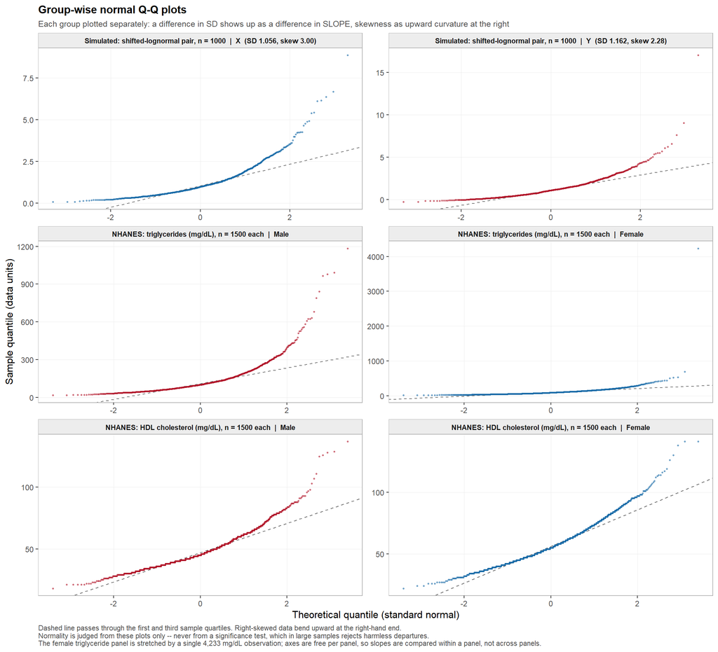

그림 1. 군별 정규 Q-Q plot. 두 군을 반드시 따로 그려야 분산 차이가 기울기 차이로 보인다. 정규성 검정은 쓰지 않았다 — 논문이 명시적으로 반대하는 관행이기 때문이다.

## 8.2 전체표본 검정과 효과크기

표 29. 전체표본 검정 (가중치 미적용).

| 변수 | Welch p | Student p | WMW p | Welch 자유도 | 평균차 (남-여) | SD비 |
| --- | --- | --- | --- | --- | --- | --- |
| LBXTR | 0 | 0 | 0 | 9804.546 | 21.2733 | 1.2949 |
| LBDHDD | 0 | 0 | 0 | 21923.315 | -9.4253 | 0.8626 |

표 30. 효과크기.

| 변수 | Cohen’s d | Hedges’ g | Glass’s Delta | Cliff’s delta | CLES |
| --- | --- | --- | --- | --- | --- |
| LBXTR | 0.206 | 0.2060 | 0.2376 | 0.1237 | 0.4382 |
| LBDHDD | -0.611 | -0.6109 | -0.5716 | -0.3646 | 0.6823 |

실제 자료에서도 빠른 구현이 base R과 일치함을 재확인했다 (max |welch_p − t.test| = 3.62e-40).

## 8.3 구간추정의 언어 — 축이 다르다

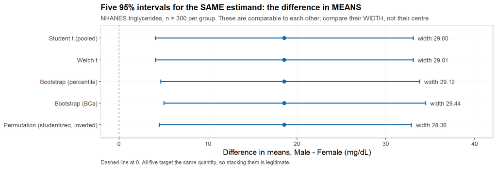

그림 3a. 같은 추정량(평균 차이)에 대한 다섯 가지 95% 구간. NHANES 중성지방, 각 군 300명. 비교 포인트는 구간의 중심이 아니라 폭이다.

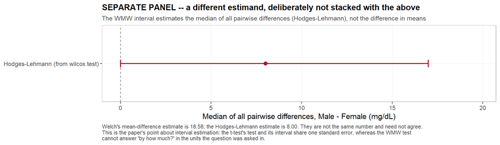

그림 3b. Hodges-Lehmann 구간은 별도 패널에 둔다. 이것은 평균차가 아니라 두 군 간 모든 쌍 차이의 중앙값에 대한 구간이므로, 위 그림에 얹으면 서로 다른 추정량을 겹쳐 놓는 셈이 된다.

전체표본에서 중성지방의 Welch 평균차 추정은 21.27 mg/dL인데 Hodges–Lehmann 추정량은 11.00 mg/dL이다. **두 배 가까이 다르다.** 오른쪽 꼬리가 평균은 끌어올리지만 쌍 차이의 중앙값은 그렇지 않기 때문이다. 이 불일치 자체가 논문의 메시지다 — t 검정은 검정과 구간추정이 같은 표준오차를 공유하지만, WMW는 “그래서 얼마나 다른데?”에 **질문한 것과 같은 언어로** 답하지 못한다.

## 8.4 재표본 분포 — p값의 정체와 중심극한정리

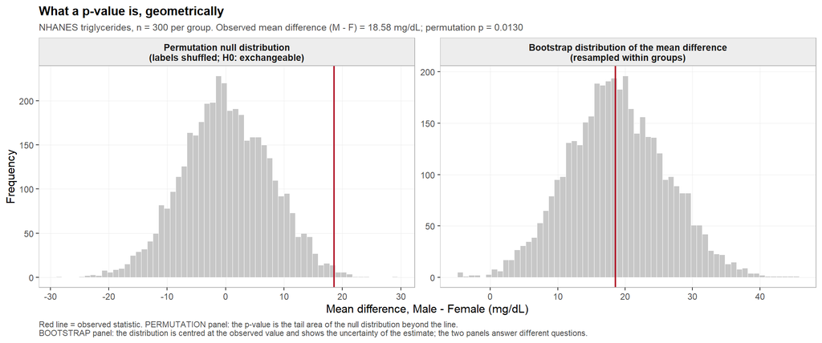

그림 2a. 순열 귀무분포와 부트스트랩 분포. 관측 통계량은 빨간 수직선. 왼쪽에서 p값은 꼬리 면적이라는 기하학적 사실이, 오른쪽에서 추정의 불확실성이 드러난다. 순열 p = 0.0130.

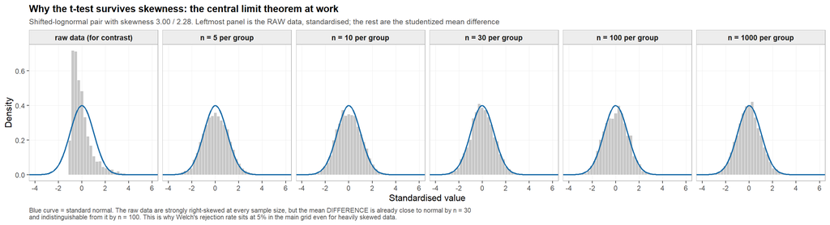

그림 2b. 원자료가 아무리 치우쳐도 평균차의 분포는 표본이 커질수록 종모양에 가까워진다. t 검정이 견고한 이유를 한 장으로 설명하는 그림이다.

## 8.5 부분표본 실험

표 31. 관측 자료에서 각 군 n명을 비복원 추출하기를 2,000회 반복.

| 변수 | 각 군 n | Welch 기각률 % | WMW 기각률 % | Welch p 중앙값 | WMW p 중앙값 | P(p_WMW<p_Welch) % | Cliff’s delta 평균 |
| --- | --- | --- | --- | --- | --- | --- | --- |
| LBXTR | 25 | 10.75 | 10.80 | 0.3379 | 0.3798 | 42.80 | 0.1247 |
| LBXTR | 50 | 20.45 | 19.60 | 0.2095 | 0.2611 | 41.70 | 0.1258 |
| LBXTR | 100 | 39.35 | 33.30 | 0.0818 | 0.1212 | 38.20 | 0.1241 |
| LBXTR | 250 | 75.45 | 67.55 | 0.0095 | 0.0150 | 36.80 | 0.1252 |
| LBXTR | 500 | 89.80 | 93.05 | 0.0004 | 0.0008 | 36.90 | 0.1234 |
| LBXTR | 1000 | 99.05 | 100.00 | 0.0000 | 0.0000 | 40.60 | 0.1237 |
| LBXTR | 2500 | 100.00 | 100.00 | 0.0000 | 0.0000 | 51.60 | 0.1234 |
| LBDHDD | 25 | 58.55 | 61.20 | 0.0306 | 0.0258 | 52.70 | -0.3639 |
| LBDHDD | 50 | 85.25 | 89.25 | 0.0025 | 0.0016 | 61.45 | -0.3628 |
| LBDHDD | 100 | 99.45 | 99.80 | 0.0000 | 0.0000 | 69.65 | -0.3656 |
| LBDHDD | 250 | 100.00 | 100.00 | 0.0000 | 0.0000 | 82.75 | -0.3634 |
| LBDHDD | 500 | 100.00 | 100.00 | 0.0000 | 0.0000 | 93.20 | -0.3642 |
| LBDHDD | 1000 | 100.00 | 100.00 | 0.0000 | 0.0000 | 98.75 | -0.3642 |
| LBDHDD | 2500 | 100.00 | 100.00 | 0.0000 | 0.0000 | 100.00 | -0.3649 |

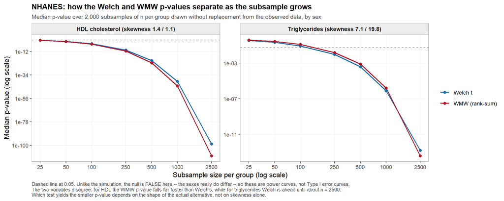

그림 7. 부분표본 크기에 따른 Welch와 WMW의 p값 분리. 모의실험과 달리 여기서는 귀무가설이 거짓이므로 이 곡선들은 제1종 오류율이 아니라 검정력 곡선이다.

**예상과 달랐던 점을 그대로 보고한다.** 논문은 “WMW가 평균적으로 더 작은 p값을 낸다”고 하지만, 중성지방에서는 각 군 2,500명이 되기 전까지 **Welch의 p값이 더 작다**(P(p_WMW < p_Welch)가 n = 25–1000 구간에서 36.8–42.8%). HDL에서는 반대로 WMW가 압도한다(n = 2,500에서 100%). 두 변수가 정반대로 갈린 것이다.

이유는 어느 검정이 이기는지가 **왜도가 아니라 실제 대립가설의 모양**에 달려 있기 때문이다. 중성지방은 남녀 평균차(21.3)가 크지만 순위 기반 효과 (Cliff’s $\delta$ = 0.124)는 상대적으로 작고, HDL은 순위 기반 효과가 훨씬 크다 ($\delta$ = -0.365). 논문의 결과는 **귀무가설이 참인** 설정에서 얻은 것이므로 여기에 그대로 옮겨지지 않는다. 이 점을 흐리지 않고 적어 둔다.

## 8.6 복합표본설계에 대한 단서 — 반드시 읽을 것

NHANES는 단순임의표본이 아니라 **층화·군집 복합표본설계**이고 표본가중치가 딸려 있다. 위의 모든 검정은 **가중치를 적용하지 않은** 것이다. 이 과제의 목적이 **검정들 사이의 비교**라면 단순 비교로도 되지만, **모집단 추론에는 쓸 수 없다.**

표 32. survey::svyttest 설계기반 참조 분석. 설계 자유도는 PSU 수에서 층 수를 뺀 71로, 표본크기 수만이 아니라 군집 수가 정밀도를 결정함을 보여준다.

[output not shown]